# R Notebook

Load packages needed for analysis

```r
library(tidyverse)
library(stringr)
```

Load Bob Jenkins’ data. Includes counts and measurements that he collected between 1970-ish and 1990-ish. Includes most, if not all, specimens in musuems at the time.

```r
mer_table<-read_csv(file = "AUSCON.csv")
mer_table
```

| FORM | COLL_NUM | DRAINAGE | SYSTEM | COUNTRY | STATE | COUNTY | STREAM | DATE | SPM. | SL | TL | WT | SEX | STAGE | GONAD | TUBERCLES | VERT | LL_SC | CB_SC | CB_U | CB_L | CP_SC | CP_ROW | PD_SC | BR_SC | P1 | P2_L | P2_R | D | … |
| --- | --- | --- | --- | --- | --- | --- | --- | --- | --- | --- | --- | --- | --- | --- | --- | --- | --- | --- | --- | --- | --- | --- | --- | --- | --- | --- | --- | --- | --- | --- |
| 01 con | USNM 171 | 04 SanAntonio | . | USA | TX | Bexar | Salado Cr | 1851---- | . | 118.0 | 0.0 | 0.0 | . | . | . | . | 0 | 42 | 32 | 13 | 17 | 16 | 0 | 0 | 0 | 17 | 10 | 9 | 12 | … |
| 01 con | USNM 164525 | 01 Brazos | . | USA | TX | Bell | Salado Cr | . | . | 95.0 | 0.0 | 0.0 | . | . | . | . | 0 | 45 | 33 | 13 | 18 | 16 | 0 | 0 | 0 | 17 | 9 | 9 | 12 | … |
| 01 con | TNHC 4148 | 01 Brazos | . | USA | TX | Bosque | Bee Cr | 19530625 | 27 | 56.0 | 0.0 | 0.0 | . | . | . | . | 0 | 44 | 0 | 0 | 0 | 16 | 0 | 0 | 0 | 16 | 9 | 8 | 11 | … |
| 01 con | TNHC 4148 | 01 Brazos | . | USA | TX | Bosque | Bee Cr | 19530625 | 23 | 56.0 | 0.0 | 0.0 | . | . | . | . | 0 | 44 | 35 | 14 | 19 | 16 | 0 | 0 | 0 | 17 | 9 | 9 | 12 | … |
| 01 con | TNHC 4148 | 01 Brazos | . | USA | TX | Bosque | Bee Cr | 19530625 | . | 51.6 | 0.0 | 0.0 | . | . | . | . | 0 | 44 | 33 | 13 | 18 | 16 | 0 | 0 | 0 | 16 | 9 | 9 | 11 | … |
| 01 con | TNHC 4148 | 01 Brazos | . | USA | TX | Bosque | Bee Cr | 19530625 | 5 | 50.6 | 0.0 | 0.0 | . | . | . | . | 0 | 43 | 33 | 14 | 17 | 16 | 0 | 0 | 0 | 16 | 9 | 9 | 12 | … |
| 01 con | TNHC 4148 | 01 Brazos | . | USA | TX | Bosque | Bee Cr | 19530625 | 8 | 48.9 | 0.0 | 0.0 | . | . | . | . | 0 | 43 | 37 | 14 | 21 | 16 | 0 | 0 | 0 | 15 | 9 | 9 | 11 | … |
| 01 con | TNHC 4148 | 01 Brazos | . | USA | TX | Bosque | Bee Cr | 19530625 | 22 | 45.7 | 0.0 | 0.0 | . | . | . | . | 0 | 42 | 36 | 14 | 20 | 16 | 0 | 0 | 0 | 16 | 9 | 9 | 12 | … |
| 01 con | TNHC 4148 | 01 Brazos | . | USA | TX | Bosque | Bee Cr | 19530625 | 38 | 45.0 | 0.0 | 0.0 | . | . | . | . | 0 | 44 | 36 | 14 | 20 | 15 | 0 | 0 | 0 | 16 | 8 | 8 | 12 | … |
| 01 con | UMMZ 120191 | 01 Brazos | . | USA | TX | McLennan | S Bosque R | 19380621 | . | 169.0 | 0.0 | 0.0 | . | . | . | . | 0 | 43 | 33 | 15 | 16 | 16 | 0 | 0 | 100 | 17 | 9 | 9 | 12 | … |

[output cut: 697 more lines]

**Lateral Line Scales**

Summraise lateral line scales by river system (DRAINAGE) using a figure.

Bob Jenkins thought, and my own analysis confirms (Clements et al., 2014), that it is important to consider variation within major river systems.

Add some of that complexity to the plots and visualize. Size of points is the number of individuals (n). The light grey point represents the mean value.

```r
mer_table %>%
  filter(LL_SC>0) %>%
  unite(drain_sys,DRAINAGE,SYSTEM,sep="_") %>%
  ggplot(aes(x=drain_sys,y=LL_SC))+
  geom_count() +
  theme(axis.text.x=element_text(angle=0,hjust=1,vjust = 1))+
  stat_summary(fun.y="mean",geom="point",colour = "grey", size = 2,alpha=.9)+
  scale_y_continuous(breaks=seq(41,50,1))+
  coord_flip()+
  ggtitle("Lateral Line Scales")
```

[output not shown]

Fish from the Middle Rio Bravo (Alimito Creek, Rio Bravo near the Conchos and Conchos River) have higher lateral line scale counts (>45). This population is genetically divergent (Clements et al. 2014) from other described species in Mexico.

The Rio Mezquital and San Pedro?_Lerma? (i.e.,*Scartomyzon milleri*) inhabit a separate, Pacific slope drainage and have similar counts as fish of the Rio Conchos.

The fish found in the Lower Rio Grande de Santiago (a separate pacific slope drainage that includes several several sub-systems – Balanos, Juchipila, San Nichols, Huyamamato, Verde) have a high lateral line counts, but lower mean counts than the Conchos and Rio Mezquital.

Fish from above Lake Chapala (Rio Lerma = type Locality for *S. austrinus*) have fewer lateral line scales (42-45) and similar to populations found in the Pacific slope flowing Ameca and Armeria drainges. The Armeria and Ameca fish represent the described *S. mascotae*.

*S. albidus* are known from the tributaries of the Lower Rio Bravo (Rio San Juan, Rio Salado) and 1 Gulf slope (Rio San Fernando) drainage of Mexico. All of these populations have counts (42-47) similar to *S. austrinus* and *S. mascotae* of the Pacific Slope.

The undescribed Rio Soto la Marina population, formerly recognized as *S. albidus*, is genetically distinct from all other *Scartomyzon* in Mexico and Texas (Clements et al. 2014). This populations has fewer average lateral line scales (42-46) than *S. albiudus*. The counts for this population are simialar to *S. congestus* (41-47) from the Gulf slope drainges (Brazos, Colorado, Guadelupe, San Antonio, Nueces). The Pecos R., recognized as *S. congestus* (Clements et al., 2014), have similar counts (44-45).

The fish from Devils R and vicinity were genetically similar to *S. congestus* (Clements et al. 2014).These fish tend to have higher counts (44-47) than other Atlantic slope and Pecos R *S. congestus* populations.They are more similar to fish from the lower Rio Bravo (Rio San Juan and Rio Salado).

**Circumbody Scales**  
Summarise circumbody scales by river system (DRAINAGE and system) with a figure. Size of points is the number of individuals (n). The light grey point represents the mean value. Include system level information for certain populations.

```r
mer_table %>%
  filter(CB_SC>0) %>%
  unite(drain_sys,DRAINAGE,SYSTEM,sep="_")%>%

  ggplot(aes(x=drain_sys,y=CB_SC))+
  geom_count() +
  theme(axis.text.x=element_text(angle=0,hjust=1,vjust = 1))+
  stat_summary(fun.y="mean",geom="point",colour = "grey", size = 2,alpha=.9)+
  scale_y_continuous(breaks=seq(30,44,1))+
  coord_flip()+
  ggtitle("Total Circumbody Scales")
```

[output not shown]

Similar to patterns observed for lateral line scale variation, Conchos River (38-43) and Lower Rio Gande de Santiago (36-43) have high scale counts.

Unlike patterns in lateral line scales, the Rio Mezquital (*S. milleri*) have fewer circumbody scales (35-38) than Conchos and lower Rio Grande de Santiago.

The Lerma (*S. austrinus, type locality) have the lowest counts (30-34).

*S. moscotae* (Aremeria and Ameca) have more circumbody scales (32-39) than nearby Rio Lerma.

*S.albiuds* (Lower Rio Bravo tribs and Atlantic slope draingages of Mexico) have 31-37 scales. The Rio Salado tends to have lower counts (31-33). The undescribe Rio Soto la Marina have simialr counts. Circumbody scales are similar for *S. congestus* (31-37) (Pecos R, Devils R, and Atlantic Slope Drainages of Texas).

**Upper Circumbody Scales**

```r
mer_table %>%
  filter(CB_U>0)%>%
  unite(drain_sys,DRAINAGE,SYSTEM,sep="_")%>%
  ggplot(aes(x=drain_sys,y=CB_U))+
  geom_count() +
  theme(axis.text.x=element_text(angle=0,hjust=1,vjust = 1))+
  stat_summary(fun.y="mean",geom="point",colour = "grey", size = 3,alpha=.9)+
  scale_y_continuous(breaks=seq(10,50,1))+
  coord_flip()+
  ggtitle("Upper Circumbody Scales")
```

[output not shown]

*S.mascotae* (Armeria and Ameca) have on average more scales (13-15) than *S.austrinus* from the Lerma (type locality) (13).

The undescribed Rio Soto la Marina and *S.albidus* have similar counts (13-15).

*S. congestus* have slightly higher average counts than *S.albidus*.

The undescribed Rio Conchos have much higher counts (15-17). The undescribed Rio Grande de Santiao have similat counts but are on average higher than Rio Conchos.

```r
mer_table %>%
  filter(CB_L>0)%>%
  unite(drain_sys,DRAINAGE,SYSTEM,sep="_")%>%
  ggplot(aes(x=drain_sys,y=CB_L))+
  geom_count() +
  theme(axis.text.x=element_text(angle=0,hjust=1,vjust = 1))+
  stat_summary(fun.y="mean",geom="point",colour = "grey", size = 3,alpha=.9)+
  scale_y_continuous(breaks=seq(10,50,1))+
  coord_flip()+
  ggtitle("Lower Circumbody Scales")
```

[output not shown]

*S. mascotae* has 17-22 scales similar to fish from the Gulf slope (Rio Soto la Marina, *S. albidus*) although two populations of *S. albidus* (Rio San Juan and Rio Salado) have on average fewer scales.

*S. austrinus* from the Rio Lerma (type locality) have fewest scales (15-19).

*S.congestus* from Texas have fewer scales on average than those in the Pecos R. and Rio Bravo (including Devils R.).

The highest scale counts are found in the Conchos R (20-24) and the Rio Grande de Santiago.

**Circum-peduncle scales**

```r
mer_table %>%
  filter(CP_SC>0)%>%
  unite(drain_sys,DRAINAGE,SYSTEM,sep="_")%>%
  ggplot(aes(x=drain_sys,y=CP_SC))+
  geom_count() +
  theme(axis.text.x=element_text(angle=0,hjust=1,vjust = 1))+
  stat_summary(fun.y="mean",geom="point",colour = "grey", size = 3,alpha=.9)+
  scale_y_continuous(breaks=seq(10,50,1))+
  coord_flip()+
  ggtitle("Circum-peduncle Scales")
```

[output not shown]

Most fish in this group have 16 caudal peduncle scales. The fish found in the Rio Grande de Santiago have higher average counts (16-20).

```r
mer_table %>%
  filter(P1>0)%>%
  unite(drain_sys,DRAINAGE,SYSTEM,sep="_")%>%
  ggplot(aes(x=drain_sys,y=P1))+
  geom_count() +
  theme(axis.text.x=element_text(angle=0,hjust=1,vjust = 1))+
  stat_summary(fun.y="mean",geom="point",colour = "grey", size = 3,alpha=.9)+
  scale_y_continuous(breaks=seq(10,50,1))+
  coord_flip()+
  ggtitle("Pectoral Fin Rays")
```

```r
mer_table %>%
  filter(P2_L>0)%>%
  unite(drain_sys,DRAINAGE,SYSTEM,sep="_")%>%
  ggplot(aes(x=drain_sys,y=P2_L))+
  geom_count() +
  theme(axis.text.x=element_text(angle=0,hjust=1,vjust = 1))+
  stat_summary(fun.y="mean",geom="point",colour = "grey", size = 3,alpha=.9)+
  scale_y_continuous(breaks=seq(7,50,1))+
  coord_flip()+
  ggtitle("Pelvic Fin Rays (Left)")
```

```r
mer_table %>%
  filter(P2_R>0)%>%
  unite(drain_sys,DRAINAGE,SYSTEM,sep="_")%>%
  ggplot(aes(x=drain_sys,y=P2_R))+
  geom_count() +
  theme(axis.text.x=element_text(angle=0,hjust=1,vjust = 1))+
  stat_summary(fun.y="mean",geom="point",colour = "grey", size = 3,alpha=.9)+
  scale_y_continuous(breaks=seq(7,50,1))+
  coord_flip()+
  ggtitle("Pelvic Fin Rays (Right)")
```

```r
mer_table %>%
  filter(D>0)%>%
  unite(drain_sys,DRAINAGE,SYSTEM,sep="_")%>%
  ggplot(aes(x=drain_sys,y=D))+
  geom_count() +
  theme(axis.text.x=element_text(angle=0,hjust=1,vjust = 1))+
  stat_summary(fun.y="mean",geom="point",colour = "grey", size = 3,alpha=.9)+
  scale_y_continuous(breaks=seq(7,50,1))+
  coord_flip()+
  ggtitle("Dorsal Fin Rays (Right)")
```

```r
mer_table %>%
  filter(LIP_A>0)%>%
  unite(drain_sys,DRAINAGE,SYSTEM,sep="_")%>%
  ggplot(aes(x=drain_sys,y=LIP_A))+
  geom_count() +
  theme(axis.text.x=element_text(angle=0,hjust=1,vjust = 1))+
  stat_summary(fun.y="mean",geom="point",colour = "grey", size = 3,alpha=.9)+
  scale_y_continuous(breaks=seq(90,180,10))+
  coord_flip()+
  ggtitle("Lip Angle")
```

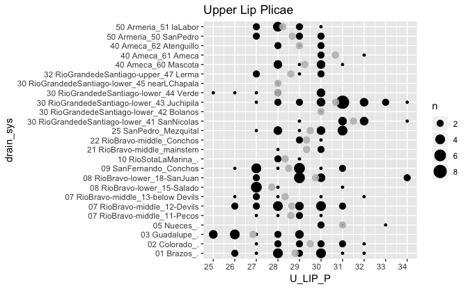

```r
mer_table %>%
  filter(U_LIP_P>0)%>%
  unite(drain_sys,DRAINAGE,SYSTEM,sep="_")%>%
  ggplot(aes(x=drain_sys,y=U_LIP_P))+
  geom_count() +
  theme(axis.text.x=element_text(angle=0,hjust=1,vjust = 1))+
  stat_summary(fun.y="mean",geom="point",colour = "grey", size = 3,alpha=.9)+
  scale_y_continuous(breaks=seq(20,40,1))+
  coord_flip()+
  ggtitle("Upper Lip Plicae")
```

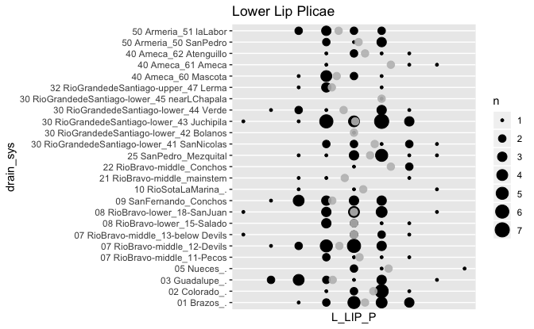

```r
mer_table %>%
  filter(L_LIP_P>0)%>%
  unite(drain_sys,DRAINAGE,SYSTEM,sep="_")%>%
  ggplot(aes(x=drain_sys,y=L_LIP_P))+
  geom_count() +
  theme(axis.text.x=element_text(angle=0,hjust=1,vjust = 1))+
  stat_summary(fun.y="mean",geom="point",colour = "grey", size = 3,alpha=.9)+
  scale_y_continuous(breaks=seq(90,180,10))+
  coord_flip()+
  ggtitle("Lower Lip Plicae")
```

```r
mer_table %>%
  mutate(species=case_when(DRAINAGE=="01 Brazos"     ~ "congestum",
                           DRAINAGE=="02 Colorado"   ~ "congestum",
                           DRAINAGE=="03 Guadalupe"  ~ "congestum",
                           DRAINAGE=="04 SanAntonio" ~ "congestum",
                           DRAINAGE=="05 Nueces"     ~ "congestum",
                           SYSTEM=="11-Pecos"        ~ "congestum",
                           SYSTEM=="10-upper"        ~ "congestum",
                           SYSTEM=="12-Devils"       ~ "albidus",
                           SYSTEM=="18-SanJuan"      ~ "albidus",
                           SYSTEM=="15-Salado"       ~ "albidus",
                           DRAINAGE=="09 SanFernando"~ "albidus",
                           DRAINAGE=="10 RioSotaLaMarina" ~ "alb_spp",
                           SYSTEM=="13-below Devils" ~ "congestum")) %>%
  filter(species=="congestum" |
         species=="albidus" |
         species=="alb_spp") %>%
  filter(LL_SC > 0 & CB_U>0 & CB_L >0 & D>0 ) %>%
  prcomp(~LL_SC+CB_U,+CB_L+D,data=.,scale = F,center=T)->pca
```

```r
pca$x %>%
  as_tibble(.)%>%
ggplot() +
  geom_point(aes(PC1,PC2))

biplot(pca)
```

```r
mer_table %>%
  select(DRAINAGE,SYSTEM) %>%
  unite(DR_SYS,DRAINAGE,SYSTEM,sep="--") %>%
  unique()
```

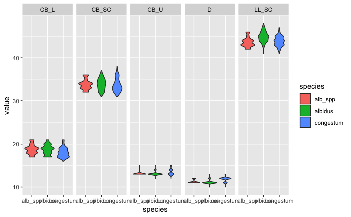

```r
mer_table %>%
  mutate(species=case_when(DRAINAGE=="01 Brazos"     ~ "congestum",
                           DRAINAGE=="02 Colorado"   ~ "congestum",
                           DRAINAGE=="03 Guadalupe"  ~ "congestum",
                           DRAINAGE=="04 SanAntonio" ~ "congestum",
                           DRAINAGE=="05 Nueces"     ~ "congestum",
                           SYSTEM=="11-Pecos"        ~ "congestum",
                           SYSTEM=="10-upper"        ~ "congestum",
                           SYSTEM=="12-Devils"       ~ "albidus",
                           SYSTEM=="18-SanJuan"      ~ "albidus",
                           SYSTEM=="15-Salado"       ~ "albidus",
                           DRAINAGE=="09 SanFernando"~ "albidus",
                           DRAINAGE=="10 RioSotaLaMarina" ~ "alb_spp",
                           SYSTEM=="13-below Devils" ~ "congestum")) %>%
  filter(species=="congestum" |
         species=="albidus" |
         species=="alb_spp") %>%
  group_by(species) %>%
  gather(morph,value,LL_SC,CB_SC,CB_U,CB_L,D)%>%
  filter(value!=0)%>%
  ggplot(aes(x=species,y=value))+
  geom_violin((aes(fill=species)))+
  facet_grid(.~morph,scales = "free",shrink = T)
```

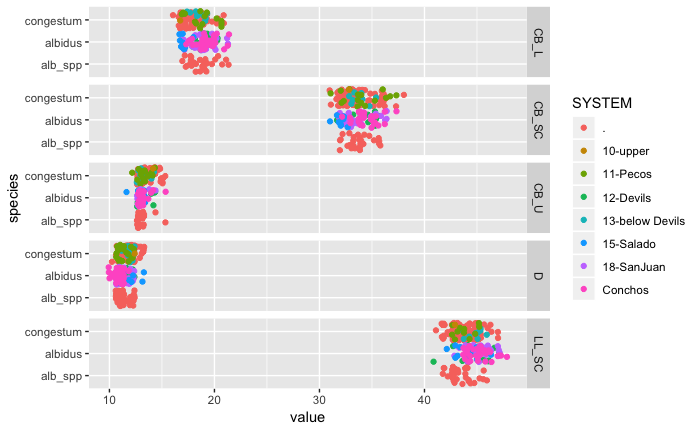

```r
mer_table %>%
  mutate(species=case_when(DRAINAGE=="01 Brazos"     ~ "congestum",
                           DRAINAGE=="02 Colorado"   ~ "congestum",
                           DRAINAGE=="03 Guadalupe"  ~ "congestum",
                           DRAINAGE=="04 SanAntonio" ~ "congestum",
                           DRAINAGE=="05 Nueces"     ~ "congestum",
                           SYSTEM=="11-Pecos"        ~ "congestum",
                           SYSTEM=="10-upper"        ~ "congestum",
                           SYSTEM=="12-Devils"       ~ "albidus",
                           SYSTEM=="18-SanJuan"      ~ "albidus",
                           SYSTEM=="15-Salado"       ~ "albidus",
                           DRAINAGE=="09 SanFernando"~ "albidus",
                           DRAINAGE=="10 RioSotaLaMarina" ~ "alb_spp",
                           SYSTEM=="13-below Devils" ~ "congestum")) %>%
  filter(species=="congestum" |
         species=="albidus" |
         species=="alb_spp") %>%
  group_by(species) %>%
  gather(morph,value,LL_SC,CB_SC,CB_U,CB_L,D)%>%
  filter(value!=0)%>%
  ggplot(aes(x=value,y=species))+
  geom_jitter((aes(color=SYSTEM)))+
  facet_grid(morph~.,scales = "free",shrink = T)
```

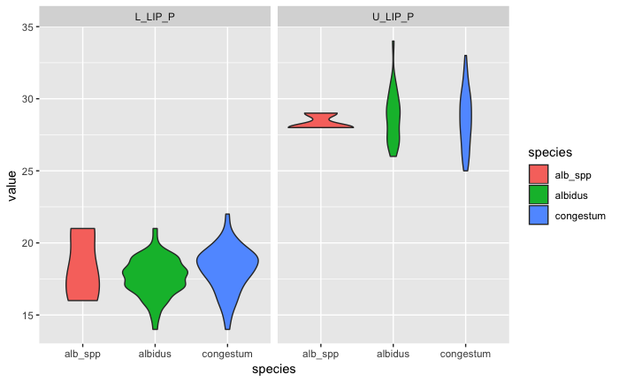

```r
mer_table %>%
  mutate(species=case_when(DRAINAGE=="01 Brazos"     ~ "congestum",
                           DRAINAGE=="02 Colorado"   ~ "congestum",
                           DRAINAGE=="03 Guadalupe"  ~ "congestum",
                           DRAINAGE=="04 SanAntonio" ~ "congestum",
                           DRAINAGE=="05 Nueces"     ~ "congestum",
                           SYSTEM=="11-Pecos"        ~ "congestum",
                           SYSTEM=="10-upper"        ~ "congestum",
                           SYSTEM=="12-Devils"       ~ "albidus",
                           SYSTEM=="18-SanJuan"      ~ "albidus",
                           SYSTEM=="15-Salado"       ~ "albidus",
                           DRAINAGE=="09 SanFernando"~ "albidus",
                           DRAINAGE=="10 RioSotaLaMarina" ~ "alb_spp",
                           SYSTEM=="13-below Devils" ~ "congestum")) %>%
  filter(species=="congestum" |
         species=="albidus" |
         species=="alb_spp") %>%
  group_by(species) %>%
  gather(morph,value,U_LIP_P,L_LIP_P)%>%
  filter(value!=0)%>%
  ggplot(aes(x=species,y=value))+
  geom_violin((aes(fill=species)))+
  facet_grid(.~morph,scales = "free",shrink = T)
```

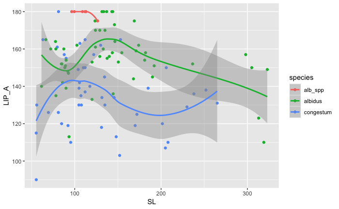

```r
mer_table %>%
  mutate(species=case_when(DRAINAGE=="01 Brazos"     ~ "congestum",
                           DRAINAGE=="02 Colorado"   ~ "congestum",
                           DRAINAGE=="03 Guadalupe"  ~ "congestum",
                           DRAINAGE=="04 SanAntonio" ~ "congestum",
                           DRAINAGE=="05 Nueces"     ~ "congestum",
                           SYSTEM=="11-Pecos"        ~ "congestum",
                           SYSTEM=="10-upper"        ~ "congestum",
                           SYSTEM=="12-Devils"       ~ "albidus",
                           SYSTEM=="18-SanJuan"      ~ "albidus",
                           SYSTEM=="15-Salado"       ~ "albidus",
                           DRAINAGE=="09 SanFernando"~ "albidus",
                           DRAINAGE=="10 RioSotaLaMarina" ~ "alb_spp",
                           SYSTEM=="13-below Devils" ~ "congestum")) %>%
  filter(species=="congestum" |
         species=="albidus" |
         species=="alb_spp") %>%
  group_by(species) %>%
  select(SL,LIP_A)%>%
  filter(LIP_A!=0 & SL!=0)%>%
  ggplot(aes(y=LIP_A,x=SL,color=species))+
  geom_point(aes(color=species))+
  geom_smooth()
```

[figure not shown]